# 第1回 課題の答え合わせ

データの探索：基本TODO①〜④と応用①②③

## 基本TODO①：気になる列を挙げる

```python
print(df[['temp', 'atemp', 'season', 'weathersit']].describe().round(2))
print('temp と atemp の相関:', round(df['temp'].corr(df['atemp']), 3))
```

```
         temp   atemp  season  weathersit
count  731.00  731.00  731.00      731.00
mean     0.50    0.47    2.50        1.40
std      0.18    0.16    1.11        0.54
min      0.06    0.08    1.00        1.00
25%      0.34    0.34    2.00        1.00
50%      0.50    0.49    3.00        1.00
75%      0.66    0.61    3.00        2.00
max      0.86    0.84    4.00        3.00
temp と atemp の相関: 0.992
```

- `temp` と `atemp`：平均 **0.50 / 0.47**、標準偏差 **0.18 / 0.16**、相関 **0.992**。そっくりな双子
- `season`・`weathersit`：数値の顔をしたカテゴリ。大小に意味がない

## 基本TODO②：散布図を描く

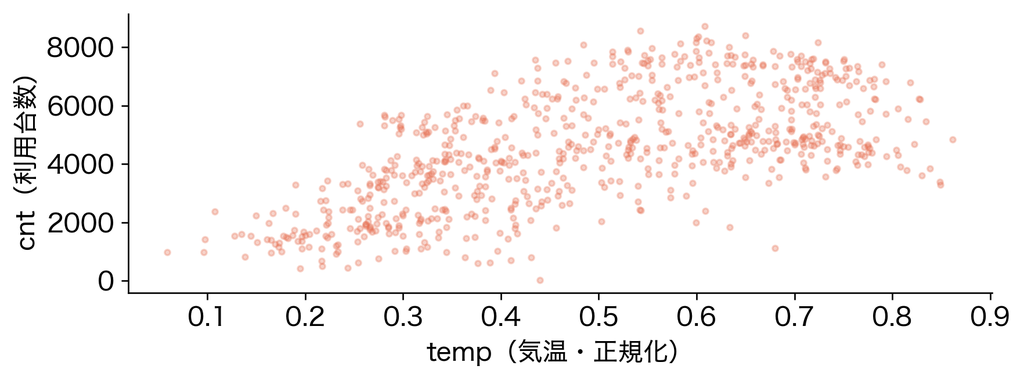

```python
fig, ax = plt.subplots(figsize=(8, 2.6))
ax.scatter(df['temp'], df['cnt'], alpha=0.3, s=8, color='#e76f51')
ax.set_xlabel('temp（気温・正規化）'); ax.set_ylabel('cnt（利用台数）')
plt.show()
```

- 全体は右上がり。ただし右端（暑すぎる日）は伸びが止まる。直線とは限らない

## 基本TODO③：相関の上位3変数

```python
corr_sorted = df.corr(numeric_only=True)['cnt'].drop('cnt').sort_values(ascending=False)
print(corr_sorted.head(3))
```

```
atemp    0.631066
temp     0.627494
yr       0.566710
Name: cnt, dtype: float64
```

- `cnt` 自身との相関 1.0 を `drop` してから並べ替える
- 上位は **atemp 0.631、temp 0.627、yr 0.567**。双子がほぼ同点で最上位
- 7節のヒートマップでは 0.63 と 0.63 に丸まって並ぶ。細かい差に意味はない

## 基本TODO④：外れ幅を縮める

```python
def mae(keys):
    pred = df.groupby(keys, observed=True)['cnt'].transform('mean')
    return round((df['cnt'] - pred).abs().mean())

for keys in [['気温帯', 'yr', 'weathersit'], ['気温帯', 'yr', 'season'],
             ['mnth', 'yr'], ['mnth', 'yr', 'weathersit']]:
    print(keys, '→', mae(keys), '台')
```

```
['気温帯', 'yr', 'weathersit'] → 665 台
['気温帯', 'yr', 'season'] → 629 台
['mnth', 'yr'] → 717 台
['mnth', 'yr', 'weathersit'] → 593 台
```

- 解答例は **気温帯×年×季節で 629台**。月×年×天気なら **593台**
- 決まった正解はない。**665台**（気温帯×年×天気）より小さくできていれば十分

## TODO④の読み方：縮むほど、疑う

```python
for keys in [['mnth', 'yr', 'weathersit', 'weekday'], ['mnth', 'yr', 'weathersit', 'weekday', '気温帯']]:
    g = df.groupby(keys, observed=True)['cnt']
    print(len(keys), '列 →', mae(keys), '台／1日だけのグループ', int((g.size() == 1).sum()), '個')
```

```
4 列 → 408 台／1日だけのグループ 101 個
5 列 → 214 台／1日だけのグループ 323 個
```

- 4列で **408台**、5列で **214台**。でも1日だけのグループが **101個 → 323個**
- 1日だけのグループは、**自分自身を答えにしている**。縮んだ分の多くは見かけ
- 作るのに使った日で採点しているかぎり、細かくするほど甘くなる → 第3回

## 応用①：時刻ごとに集計する

```
行数: 17379, 列数: 17
```

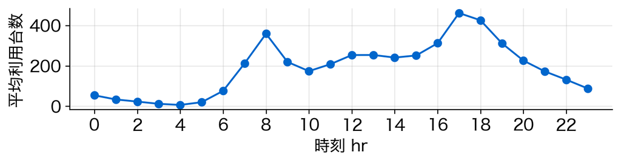

```python
hour = pd.read_csv(f'{DATA_DIR}/bike_hour.csv')
print(f'行数: {hour.shape[0]}, 列数: {hour.shape[1]}')
by_hr = hour.groupby('hr')['cnt'].mean()
fig, ax = plt.subplots(figsize=(8, 1.5))
by_hr.plot(ax=ax, marker='o', color='#0066cc'); ax.set_xticks(range(0, 24, 2)); ax.grid(alpha=0.3)
ax.set_xlabel('時刻 hr'); ax.set_ylabel('平均利用台数'); plt.show()
```

- `groupby('hr')` で時刻ごとにまとめ、`['cnt'].mean()` で平均。時刻を添字にした24行の Series

## 応用①の読み方：二つの山と谷

```python
print(by_hr.round(1).loc[[4, 8, 12, 17, 18]])
```

```
hr
4       6.4
8     359.0
12    253.3
17    461.5
18    425.5
Name: cnt, dtype: float64
```

- 朝 **8時 359台**、夕方 **17時 461.5台・18時 425.5台** の二つの山
- 深夜 **4時 6.4台** の谷。昼の12時は 253台で、山のあいだの中だるみ
- 1日1行の `bike_day` では、この形は見えなかった

## 応用②：最も多い時刻

```python
print('最大の平均台数:', round(by_hr.max(), 1))
print('答え:', int(by_hr.idxmax()))
```

```
最大の平均台数: 461.5
答え: 17
```

- 正答は **17**。`idxmax()` は最大値の**位置**（ここでは時刻）を返す
- 値そのものは `max()` で **461.5**。18時の 425.5 とは 36台の差
- グラフを目で見て答えず、コードで取り出す

## 応用③：模範例

利用は1日の中で一様ではなく、朝8時（平均359台）と夕方17〜18時（約461台・約426台）に2つの山があり、深夜4時は6台まで落ちます。

朝夕の山は通勤・通学の時間帯と重なるので、利用の中心は日常の移動と考えられます。

日次データの合計（1日平均4504台）だけでは見えない「時間帯の偏り」があるので、自転車の配置や整備はこの山に合わせて計画するのがよさそうです。

## 応用③：なぜそう書くか

- **型**：見えた形（数値）→ 解釈 → 相手への意味
- **根拠は自分の出力の数値**：8時 359台、17時 461台、4時 6台
- **日次との対比**：1日平均 4504台は、時間帯の偏りを隠す
- **相手に合わせた提案**：運営担当者なら、配置と整備の計画

AI に書かせた文との違い：「朝夕に通勤需要がある」の一般論で終わらず、**自分のグラフの数値**を根拠にしているか。

## まとめと、発展動画へ

- 基本TODO：双子（相関 0.992）、数値の顔をしたカテゴリ、上位は atemp・temp・yr
- TODO④：条件を足すと外れ幅は縮むが、1日だけのグループが増える。縮むほど疑う
- 応用①②：時刻で集計すると二つの山。最大は **17時**（461.5台）
- 応用③：日次では見えない偏りを、数値を根拠に運営担当者へ
- 粒度を変えて集計し直すだけで、新しい形が見える

発展動画：`describe`・ヒストグラム・相関を1本のレポートにまとめる **自動EDA（data-profiling）** を、ノートの発展セルで動かします。